# Beyond the Iceberg: The Factors Behind Titanic Survival

Eduardo Andrés Villarruel

2025-08-16

## Introduction

The sinking of the RMS Titanic in 1912 claimed the lives of over 800 passengers. Thanks to detailed passenger records, this event has become one of the most famous case studies in data analysis.

In this project, I aimed to do more than predict who survived — I wanted to uncover the factors that most strongly influenced survival.

This project shows how I turn raw, messy data into clear, actionable insights that anyone can understand.

The data set for the Titanic is available at kaggle.com.

## Summary

- A logistic model was fitted, achieving **82% accuracy**, close to the **84% achieved by a Random Forest benchmark**.
- **Gender was the strongest predictor:** adult women had up to 7 times higher probability of survival than men in the same conditions.
- **Age mattered mostly for men:** baby boys had up to 7 times higher probability of survival than adult men, while 10-year-old boys had up to 3.5 times higher probability. Women’s survival did not vary with age.
- **Class was also a key factor:** first-class men had about 4 times higher probability of survival than men in second or third class. Among women, those in first and second class had about 1.5 times higher probability than women in third class.

## Data Preparation

[output not shown]

**Notes on data quality**

- **Imputation:** Missing observations were estimated (imputed) to improve data quality. In particular, age was missing for about 20% of passengers. The method used was a decision tree due to is simplcity and power.
- **Consistency checks:** We also checked for duplicated observations, inconsistent information, extreme values and information lost during data entry/loading.

*These steps not only ensured data quality but also led to measurable improvements in predictive accuracy, as shown in the Results section.*

## Exploratory Analysis

Before building models, we explored the data to understand which factors were most important for survival. The goal of this step was not to predict outcomes, but to gain some insight of the data, its structure, patterns and relationships.

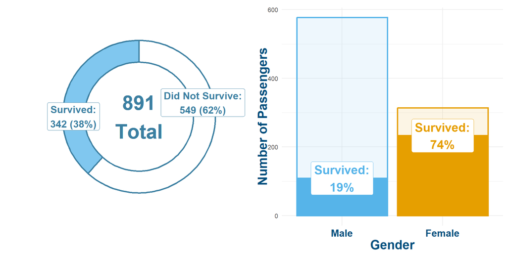

Overall, about **38% of passengers** in the training set survived.  
A striking gender gap emerged: **nearly 75% of women survived**, while **about 80% of men did not**.

We then explored how this gender effect changed when considering other factors such as **age, passenger class, and group size**.

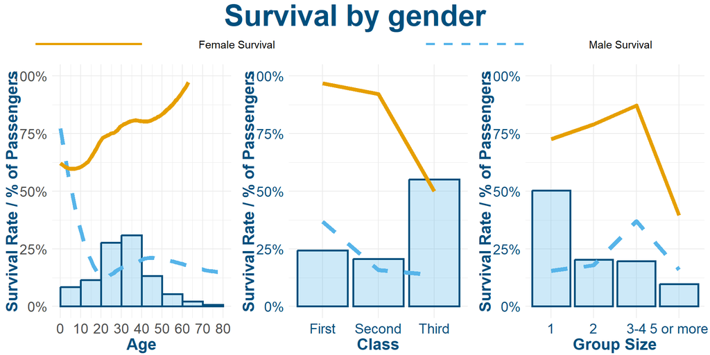

- **Gender:** Survival differed dramatically. Nearly 75% of women survived compared to less than 20% of men, making gender the strongest predictor.
- **Passenger Class:** Almost all women in first and second class survived, while in third class only about half did. Among men, survival was around 35% in first class, but dropped to just 15% in second and third class.
- **Age:** For men, boys had much higher survival rates than adults. For girls this advantage remained fairly stable, while for boys survival declined steadily until age 18.
- **Group Size:** Passengers traveling alone or in very large groups had lower survival, while those in small groups had the best chances. This might be reflecting the presence of women and children in those groups.

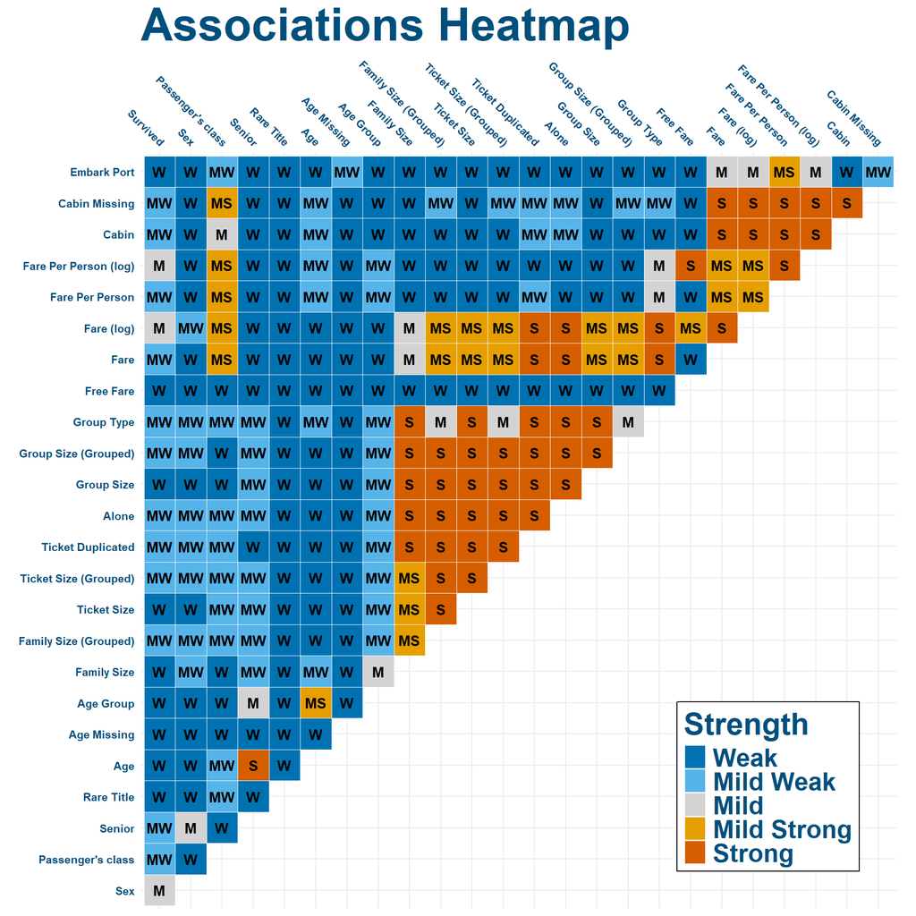

The heatmap shows how strongly the variables in our dataset are related to each other.  
When two variables are very strongly related, they tend to carry the same information. While this does not reduce prediction accuracy, it makes results harder to interpret and can make models less stable.

Because our goal is **clear interpretation**, we removed redundant variables. When faced with overlap, we kept the variable that was easier to explain and more informative, and checked that predictive performance did not suffer.

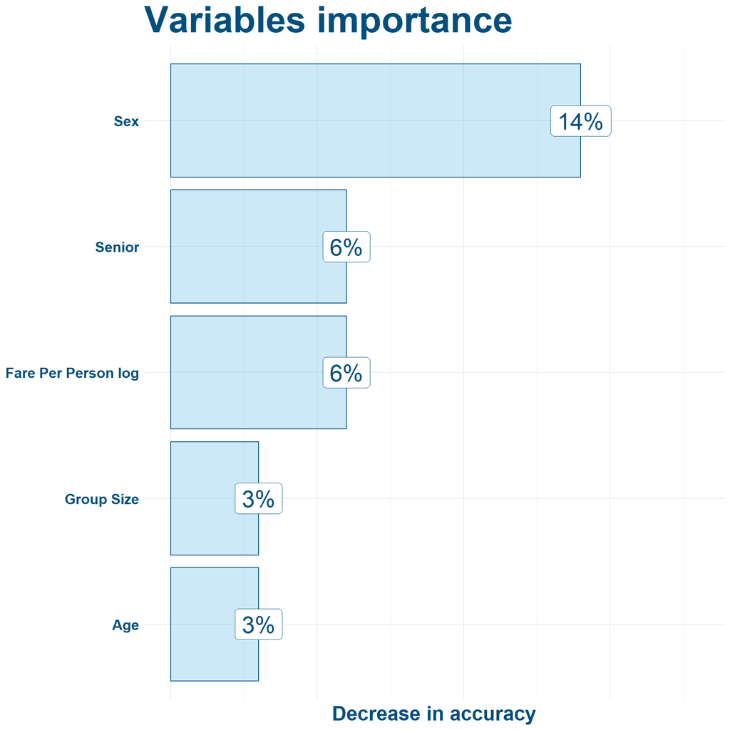

Finally, we measured **variable importance** using a random forest model. Random forests are powerful because they can detect complex relationships automatically, without us having to pre-specify them.  
The plot shows how much accuracy the model loses when each variable is removed: the bigger the drop, the more important the variable.

- The strongest predictors were **Sex**, passenger title (Mr., Mrs., Miss, Master), and **Fare per Person** (closely tied to class).
- Other factors such as **Age** (closely related to title) and **Group Size** also added meaningful information, but with smaller impact.

## Model Fitting

### Benchmarking the Models

To establish a baseline, we first implemented a Random Forest which was mentioned in the previous section, due to its ability to handle outliers and detect complex relationships. However, while Random Forest achieves high accuracy, it offers little interpretability. The table below shows how each step improved accuracy:

| Model | Accuracy | Improvement |
| --- | --- | --- |
| Base | 61.5% | – |
| Original variables | 74.3% | +12.8% |
| Imputed values | 75.6% | +1.3% |
| Created Variables | 82.3% | +6.7% |
| Selected Variables | 83.7% | +1.4% |

The model with uncorrelated variables became our benchmark. The Random Forest achieved an accuracy of 83.7%, and our goal with the parametric (interpretable) model is to approach this level of performance without sacrificing clarity. It is worth to notice that the model with **all variables** performed almost equal to the model with **selected variables**. This indicates that no information was lost during the variable selection.

### Model Selection

We followed a stepwise approach to build each model:

- **Main effects only:** start with the basic variables, remove non-contributing variables (BIC criteria).
- **Interactions:** add the interactions to model complex relationships, remove those without impact (BIC criteria).
- **Refinements:** include additional variables and interactions suggested by the exploratory analysis. A final check was performed keeping only those with significant effects (p-value criteria).

This process was applied to four different link functions. Their predictive accuracies are shown below:

| Model | Accuracy | Notes |
| --- | --- | --- |
| Linear | 82.6% | Simple, models the probability directy. It has issues when probabilities are too close to 0% or 100% |
| Logit | 81.9% | Models the odds, allowing for better properties |
| Probit | 83.1% | Achieves similar results to Logit, but based on the normal distribution |
| Cloglog | 79.1% | Usefull when we have groups with very low or very high probability of survival |

## Model Diagnosis

To ensure our model was reliable, we performed several quality checks. The table below summarizes each check and its result.

| Check | Method | Result |
| --- | --- | --- |
| Outliers | Pearson residuals vs. predicted, Cook’s Distance | 5 unusual cases found |
| Functional form | RESET test | Passed after removing outliers |
| Multicollinearity | VIF (main effects only) | No concerning collinearity |
| Goodness of fit | Hosmer–Lemeshow test | Good fit |
| Predictive power | ROC curve, AUC, Accuracy | Good discrimination power |

One important finding was the presence of **five unusual cases**. These were 30-year-old men traveling together in a large group in third class, a profile that otherwise had the lowest survival chances. Yet all five survived. Further investigation revealed they were Cantonese sailors travelling together, and around Titanic lore they are a well-known group who escaped by forcing their way onto lifeboats. Their unique situation explains why they appeared as outliers in the data, but it also highlights how individual stories can diverge from the general patterns our model describes.

# Conclusions

**Gender:**

- The effect of gender varied substantially depending on both age and passenger class.
- Among children (age 10), girls had between 10% higher and up to 2 times higher probabilities of survival than boys, depending on travel class.
- Among adults (age 30), women had between 2 and 7 times higher probabilities of survival than men, again varying by class.

**Age:**

- Men: Babies had 2 to 7 times higher survival probabilities than 30-year-old men. A 5-year-old had 2 to 5 times higher, a 10-year-old had 1.5 to 3.5 times higher, and a 15-year-old had up to 1.5 times higher, depending on class.
- Women: Age did not play a significant role in survival.

**Passenger’s class:**

- Men: First-class men had about 4 times higher survival probabilities than men in second or third class (52% vs. 14%).
- Women: First- and second-class women had around 1.5 times higher probabilities than third-class women (97% vs. 62%).

**Group Size:**

- Men: Among 30-year-olds, those traveling in small groups (1–4 people) had 5 to 8 times higher survival probabilities than men in larger groups (5+). The effect was strongest in lower classes.
- Women: The effect was smaller, with survival probabilities ranging from about 10% higher to 4 times higher compared to those in large groups, again more pronounced in lower classes.

**Interpretation note (example):**

- *When we say “babies had 7 times higher survival probabilities than 30-year-old men,” this means that if, in a given setting, 10 out of 100 men survived, we would expect 70 out of 100 babies to survive under the same conditions.*

# Final Test & Future Improvements

We trained our model on 891 observations where the outcome (passenger survival) was known. In addition, we had 418 observations with unknown outcomes — our test set. We applied the model to these passengers and submitted the predictions to Kaggle. Based on our earlier benchmarks, we expected an accuracy close to **82%**.

After submission, Kaggle reported a final score of **78%**.

- **Group survival**: Many passengers traveled together. Modeling survival at the group level first, and then assigning probabilities to individuals, could improve accuracy.
- **Family roles**: Roles within a group (e.g., father, mother, child) may provide additional predictive power.
- **Family ties and nationality**: Surnames might help reconstruct family relationships, and help deduce their nationality.
- **Advanced methods**: Techniques like *k-Means* could help identify groups of similar profiles and flag unusual cases.
- **Black box model**: At the cost of interpretablity, we could improve precision with a black box model like *random forest*, *xgboost*, *support vector machines* or *neural networks*.

These directions could make future versions of the model more accurate and robust.